# Reporte ANCOVA

David Flores

2026-07-02

# Reporte ANCOVA base de datos *twins*

Primero cargamos las librerías necesarias así como la base de datos y se asigna a un objeto.  
Antes de llevar a cabo el análisis de covarianzas, primero se realizará un resúmen numérico y gráfico de la base de datos para verificar que sus datos sean independientes, que tengan homogeneidad de varianzas y que los residuales tengan una distribución normal

## Resumen numérico

```r
lapply(split(R7,R7$Social),summary)
```

```
## $high
##      Foster        Biological       Social
##  Min.   : 80.0   Min.   : 82.0   high  :7
##  1st Qu.: 85.0   1st Qu.: 90.5   low   :0
##  Median :108.0   Median :115.0   middle:0
##  Mean   :103.3   Mean   :107.6
##  3rd Qu.:116.5   3rd Qu.:122.0
##  Max.   :132.0   Max.   :131.0
##
## $low
##      Foster         Biological        Social
##  Min.   : 63.00   Min.   : 68.00   high  : 0
##  1st Qu.: 86.25   1st Qu.: 85.50   low   :14
##  Median : 95.00   Median : 93.50   middle: 0
##  Mean   : 93.71   Mean   : 91.21
##  3rd Qu.:104.00   3rd Qu.: 97.00
##  Max.   :113.00   Max.   :111.00
##
## $middle
##      Foster         Biological        Social
##  Min.   : 71.00   Min.   : 78.00   high  :0
##  1st Qu.: 78.25   1st Qu.: 79.75   low   :0
##  Median : 90.50   Median : 89.50   middle:6
##  Mean   : 88.83   Mean   : 90.50
##  3rd Qu.: 94.50   3rd Qu.: 99.25
##  Max.   :111.00   Max.   :107.00
```

```r
summarySE(R7,measurevar="Foster",groupvars="Social")
```

```
##   Social  N    Foster       sd       se        ci
## 1   high  7 103.28571 20.10567 7.599230 18.594646
## 2    low 14  93.71429 13.89758 3.714286  8.024226
## 3 middle  6  88.83333 14.53845 5.935299 15.257173
```

```r
summarySE(R7,measurevar="Biological",groupvars="Social")
```

```
##   Social  N Biological       sd       se        ci
## 1   high  7  107.57143 19.81462 7.489221 18.325464
## 2    low 14   91.21429 12.05869 3.222821  6.962482
## 3 middle  6   90.50000 12.37336 5.051402 12.985043
```

Con la función *lapply* nos facilita la observación de las medidas centrales y de posición como la media, la mediana así como los cuartiles, además nos permite observar los resultados agrupados en base al factor social de la base de datos, nos da las medidas centrales de acuerdo al nivel social presente en la bse de datos.  
En estos resultados podemos observar que la media y la mediana de los tres niveles sociales son cercanas entre sí, además de contar con un rango similar con excepción del nivel social alto que cuenta con un rango más amplio que los demás niveles.  
Con las medidas de dispersión nos arroja datos similares, la desviación estándar es más cercana entre los grupos bajos y medios de la categoría social mientras que el grupo alto presenta diferencias con los demás.

## Resumen gráfico

Para observar estos resultados primero se harán boxplots para observar los resultados de las medidas centrales y posteriormente una gráfica de puntos para observar la distribución de estos datos.

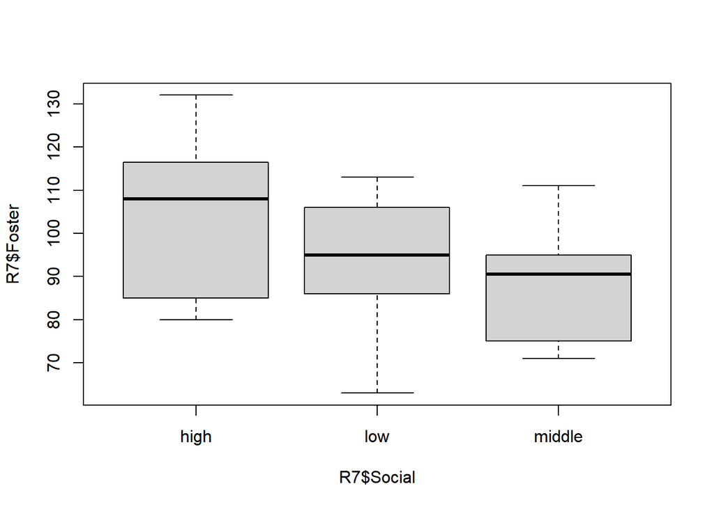

```r
boxplot(R7$Foster~R7$Social)
```

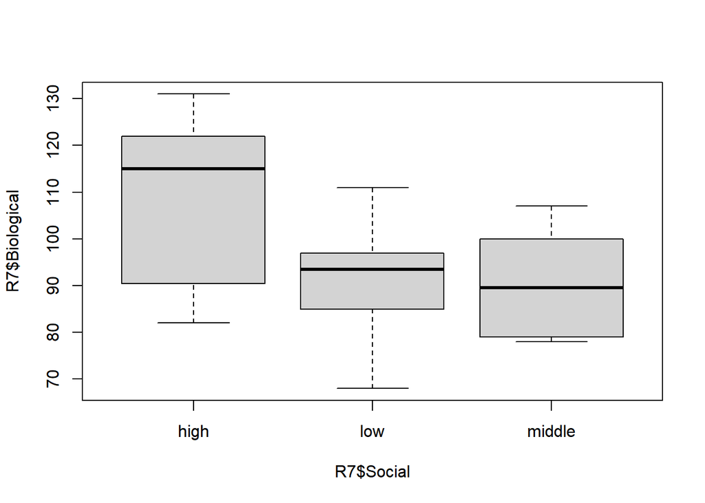

```r
boxplot(R7$Biological~R7$Social)
```

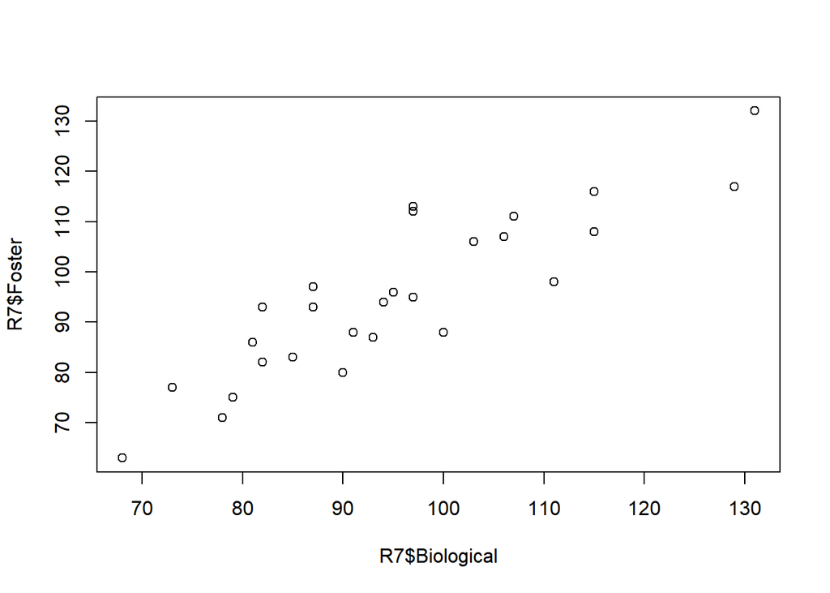

```r
plot(R7$Biological,R7$Foster)
```

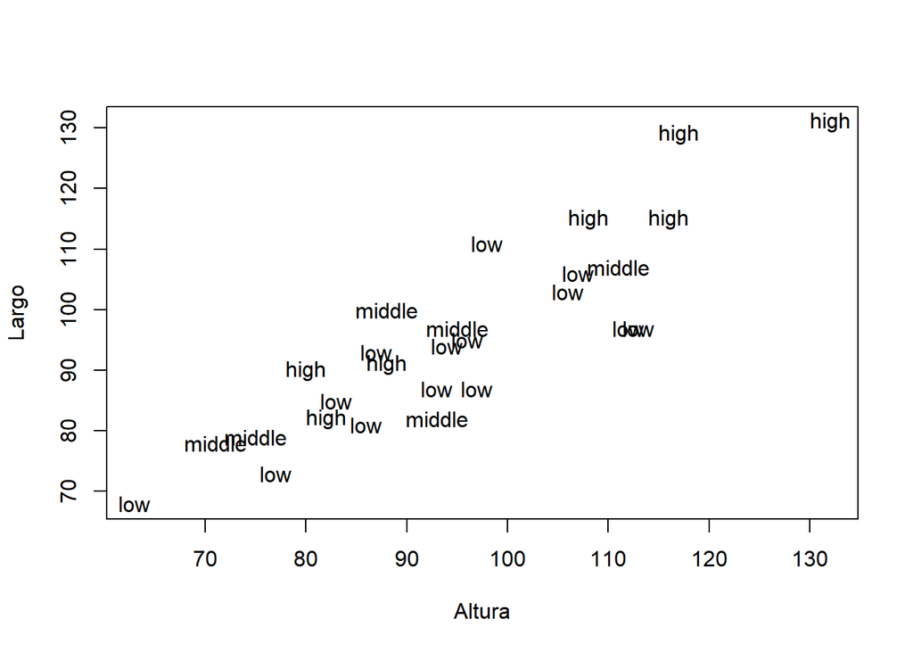

```r
plot(R7$Foster,R7$Biological,
     type="n",
     xlab="Altura",
     ylab="Largo")
text(R7$Foster,R7$Biological,as.character(R7$Social))
```

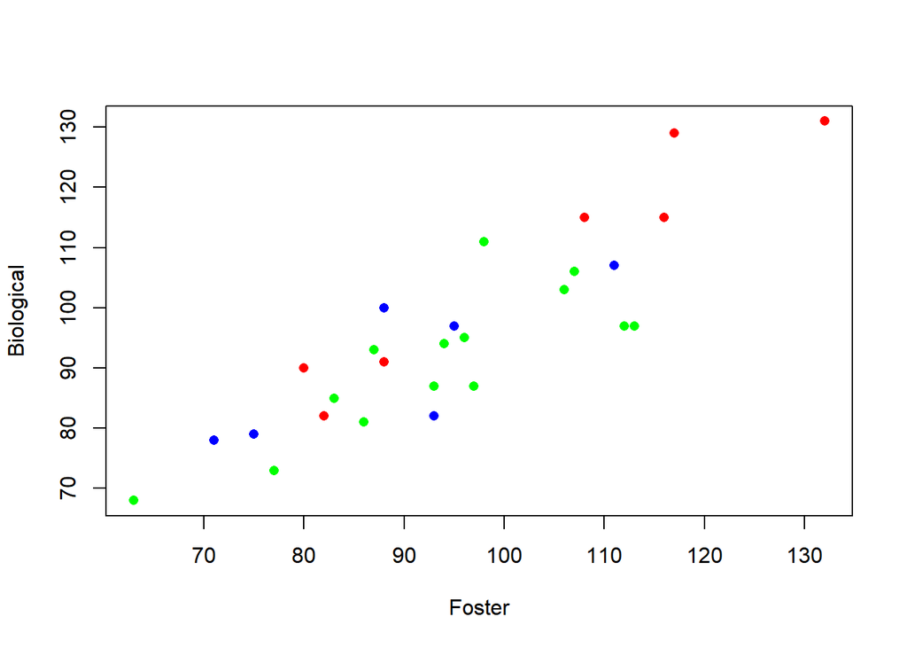

```r
plot(R7$Foster,R7$Biological,
     pch=16,
     col=(rainbow(3))[R7$Social],
     xlab="Foster",
     ylab="Biological")
```

Estos gráficos nos ilustran lo que ya determinamos en los análisis numéricos, que el grupo social medio y bajo son más parecidos entre si que el grupo social alto, en el gráfico de puntos se aprecia una separación leve en estos grupos siendo los puntos de color rojo, que están más arriba y hay 1 o 2 que se mezclan con los demás grupos mientras que el grupo bajo y medio prácticamente no hay diferencia, todos están mezclados entre si.

## Relaciones

Ahora se harán anovas para determinar si hay alguna relación entre las variables *Foster*, *Biological* y *Social*

```r
d0<-aov(Foster~Social, data=R7)
summary(d0)
```

```
##             Df Sum Sq Mean Sq F value Pr(>F)
## Social       2    732   365.8   1.465  0.251
## Residuals   24   5993   249.7
```

```r
d1<-aov(Biological~Social,data=R7)
summary(d1)
```

```
##             Df Sum Sq Mean Sq F value Pr(>F)
## Social       2   1426   713.0   3.415 0.0495 *
## Residuals   24   5012   208.8
## ---
## Signif. codes:  0 '***' 0.001 '**' 0.01 '*' 0.05 '.' 0.1 ' ' 1
```

```r
shapiro.test(d0$residuals)
```

```
##
##  Shapiro-Wilk normality test
##
## data:  d0$residuals
## W = 0.9803, p-value = 0.869
```

```r
bartlett.test(R7$Foster~R7$Social)
```

```
##
##  Bartlett test of homogeneity of variances
##
## data:  R7$Foster by R7$Social
## Bartlett's K-squared = 1.2024, df = 2, p-value = 0.5482
```

```r
shapiro.test(d1$residuals)
```

```
##
##  Shapiro-Wilk normality test
##
## data:  d1$residuals
## W = 0.96825, p-value = 0.5563
```

```r
bartlett.test(R7$Biological~R7$Social)
```

```
##
##  Bartlett test of homogeneity of variances
##
## data:  R7$Biological by R7$Social
## Bartlett's K-squared = 2.313, df = 2, p-value = 0.3146
```

Donde se observa que para ambos casos si hay una distribución normal de los residuales así como homogeneidad de varianzas enl a base de datos

## ANCOVA

Finalmente realizaremos el ancova para estos datos.

```r
an1<-lm(Foster~Biological*Social, data=R7)
shapiro.test(an1$residuals)#si es normal
```

```
##
##  Shapiro-Wilk normality test
##
## data:  an1$residuals
## W = 0.98151, p-value = 0.8947
```

```r
ncvTest(an1)#no hay heterocisticidad
```

```
## Non-constant Variance Score Test
## Variance formula: ~ fitted.values
## Chisquare = 0.365162, Df = 1, p = 0.54565
```

```r
durbinWatsonTest(an1)#independientes
```

```
##  lag Autocorrelation D-W Statistic p-value
##    1      -0.1142809      2.058968    0.39
##  Alternative hypothesis: rho != 0
```

```r
summary(an1)
```

```
##
## Call:
## lm(formula = Foster ~ Biological * Social, data = R7)
##
## Residuals:
##     Min      1Q  Median      3Q     Max
## -14.479  -5.248  -0.155   4.582  13.798
##
## Coefficients:
##                          Estimate Std. Error t value Pr(>|t|)
## (Intercept)             -1.872044  17.808264  -0.105    0.917
## Biological               0.977562   0.163192   5.990 6.04e-06 ***
## Sociallow                9.076654  24.448704   0.371    0.714
## Socialmiddle             2.688068  31.604178   0.085    0.933
## Biological:Sociallow    -0.029140   0.244580  -0.119    0.906
## Biological:Socialmiddle -0.004995   0.329525  -0.015    0.988
## ---
## Signif. codes:  0 '***' 0.001 '**' 0.01 '*' 0.05 '.' 0.1 ' ' 1
##
## Residual standard error: 7.921 on 21 degrees of freedom
## Multiple R-squared:  0.8041, Adjusted R-squared:  0.7574
## F-statistic: 17.24 on 5 and 21 DF,  p-value: 8.31e-07
```

Como se cumplen todos los supuestos no hay necesidad de transformar los datos, y el modelo se ajusta un 75% dado el resultado de la R cuadrada, no hay heterocedasticidad y los datos son independientes, esto contemplando la interacción entre la variable *biological* y *social*, sin embargo en el resumen del análisis, muestra que las interacciones no son significativas por lo que se repetirá el análisis omitiendo esta interacción entre variables.

```r
an2<-lm(Foster~Biological+Social,data=R7)
shapiro.test(an2$residuals)
```

```
##
##  Shapiro-Wilk normality test
##
## data:  an2$residuals
## W = 0.98157, p-value = 0.8959
```

```r
ncvTest(an2)
```

```
## Non-constant Variance Score Test
## Variance formula: ~ fitted.values
## Chisquare = 0.463472, Df = 1, p = 0.49601
```

```r
durbinWatsonTest(an2)
```

```
##  lag Autocorrelation D-W Statistic p-value
##    1      -0.1156362      2.055778   0.718
##  Alternative hypothesis: rho != 0
```

```r
summary(an2)
```

```
##
## Call:
## lm(formula = Foster ~ Biological + Social, data = R7)
##
## Residuals:
##      Min       1Q   Median       3Q      Max
## -14.8235  -5.2366  -0.1111   4.4755  13.6978
##
## Coefficients:
##              Estimate Std. Error t value Pr(>|t|)
## (Intercept)   -0.6076    11.8551  -0.051    0.960
## Biological     0.9658     0.1069   9.031 5.05e-09 ***
## Sociallow      6.2264     3.9171   1.590    0.126
## Socialmiddle   2.0353     4.5908   0.443    0.662
## ---
## Signif. codes:  0 '***' 0.001 '**' 0.01 '*' 0.05 '.' 0.1 ' ' 1
##
## Residual standard error: 7.571 on 23 degrees of freedom
## Multiple R-squared:  0.8039, Adjusted R-squared:  0.7784
## F-statistic: 31.44 on 3 and 23 DF,  p-value: 2.604e-08
```